title: “Chen lab RNA-seq version 2 with new samples” output: html_notebook #human cell lines # si RNA knockdown experiment

```r
library(pheatmap)
library(edgeR)
library(DESeq2)
library(biomaRt)
library(ggplot2)
```

Read in files. Add new samples that are technical replicates (S449).

```r
filename = "/Users/tfriedrich/Documents/chen/readcounts.txt"
counts1_old = read.table(filename, header = T,stringsAsFactors = F)
rownames(counts1_old) = counts1_old$Geneid
filename2 = "/Users/tfriedrich/Documents/chen/readcounts_newsamples.txt"
counts1_new = read.table(filename2, header=T, stringsAsFactors = F)
rownames(counts1_new) = counts1_new$Geneid
length(which(counts1_old$Geneid==counts1_new$Geneid))
```

```
## [1] 58302
```

```r
counts1 = data.frame(cbind(counts1_old, counts1_new[,7:ncol(counts1_new)]))
dim(counts1)
```

```
## [1] 58302    30
```

Remove metadata (Gene, coordinates, etc)

```r
counts2 = data.matrix(counts1[,7:ncol(counts1)])
colnames(counts2) = sub("_1_algn_Aligned", "", matrix(unlist(strsplit(colnames(counts2), "\\.")), byrow =T, ncol=6)[,3])
```

Filter out genes with low and high counts ( high counts might be mitochondrial genes)

```r
keep = rowMeans(counts2) > 5 & rowMeans(counts2) < 5000
counts3 = counts2[keep,]
```

```r
#counts4 = counts3 + 1
counts4 = counts3
```

Take the log (RPKM)

```r
y <- DGEList(counts=counts4)
fpkm_log_matrix = rpkm (y, gene.length=counts1[keep,"Length"], log = TRUE)
```

Dendrogram

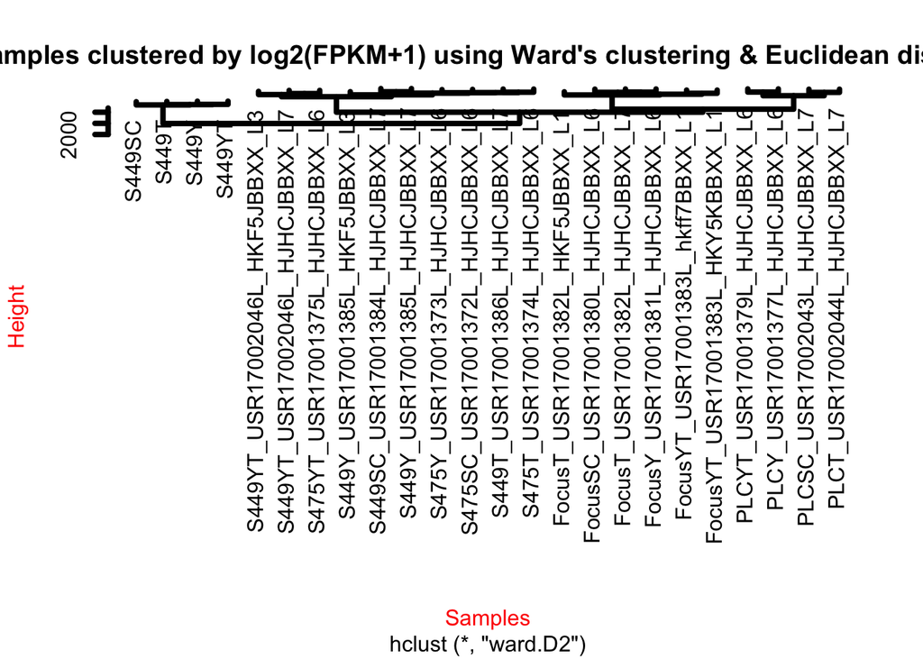

```r
hc2 <- hclust(stats::dist(t(fpkm_log_matrix), method="minkowski"), "ward.D2")
plot(hc2, lwd=4, lty=1, col="black", col.lab="red", xlab="Samples", main="Samples clustered by log2(FPKM+1) using Ward's clustering & Euclidean distance")
```

Some replicates don’t cluster (see FocusT replicates). Samples cluster by cell type. SS49 and SS475 are more similar than the other cell types.

S449 technical replicate showing batch effects.

Setup up design matrix for PCA plot

```r
groupNamesPerSample = c(matrix (unlist(strsplit(colnames(counts4[,1:20]), "_")), byrow=T, ncol=4) [,1], colnames(counts4[,21:24]))
groupNamesPerSample = unlist( lapply (groupNamesPerSample, function(x) sub("S475", "", sub("S449", "", sub("PLC", "", sub("Focus", "", x))))) )
conditionFactor  <- factor(groupNamesPerSample)
subjectgroup = c(matrix (unlist(strsplit(colnames(counts4[,1:20]), "_")), byrow=T, ncol=4) [,1], colnames(counts4[,21:24]))
subjectgroup = unlist( lapply (subjectgroup, function(x) sub("SC", "", sub("YT", "", sub("T", "", sub("Y", "", x))))) )
Subject <- factor(subjectgroup)
```

PCA plot

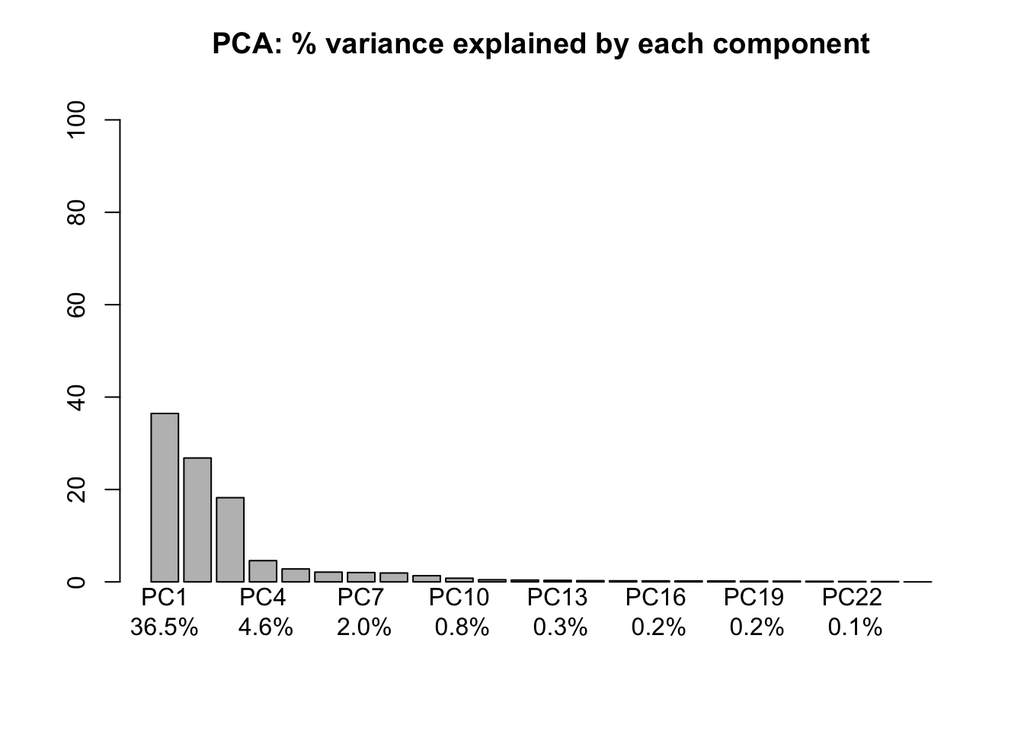

```r
cold <- data.frame("conditionFactor"=conditionFactor, "Subject"=Subject) #"sample_name"=colnames(counts4)
design_matrix <- model.matrix( ~Subject + conditionFactor)
ddsMat <- DESeq2::DESeqDataSetFromMatrix(countData=counts4, colData=cold, design=~conditionFactor);
colnames(ddsMat) <- colnames(counts4)
rld <- DESeq2::rlog(ddsMat) # LOG TRANSFORMED.

pca              <- prcomp(t(assay(rld)))
allPer.vec       <- 100 * summary(pca)$importance[2,]
allPer.text      <- paste(format(allPer.vec,digits=0, nsmall=1, scientific=FALSE), "%", sep='')
allPerLabels.vec <- paste(names(allPer.vec), "\n", allPer.text, sep='')

barplot(allPer.vec, main="PCA: % variance explained by each component\n" , ylim=c(0,100), names.arg=allPerLabels.vec)
```

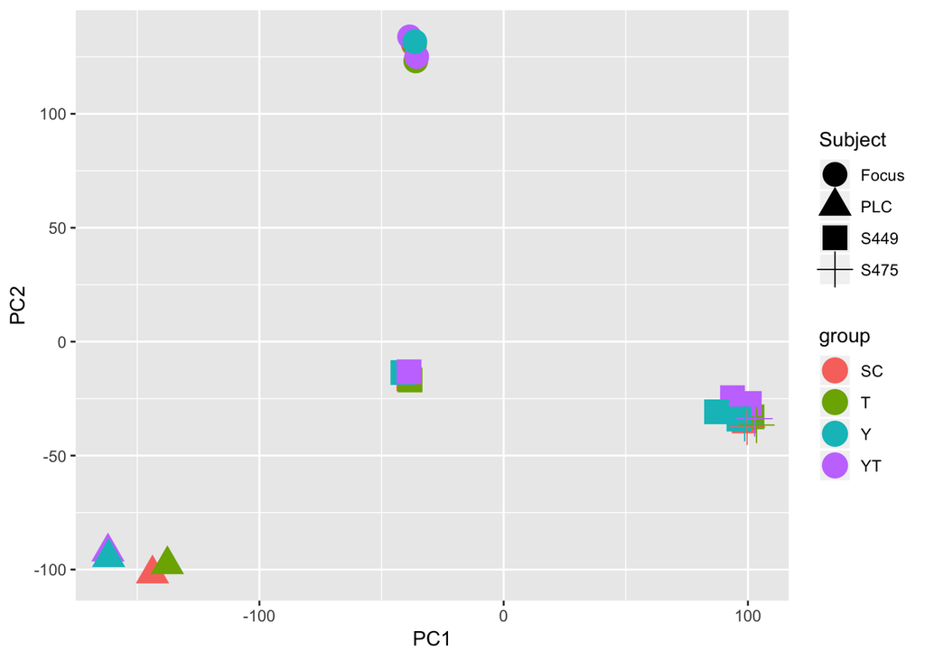

```r
d <- data.frame(pca$x, group=conditionFactor, Subject, name=colnames(rld)) # returns PC1, PC2, ... PC8... etc
ppp <- ggplot(d, aes_string(x="PC1", y="PC2", shape="Subject", color="group"))
ppp <- ppp + geom_point(size=6)
plot(ppp)
```

Samples seem to cluster by cell type. S449 and S475 appear to be very similar. Replicates cluster together mostly.

Again S449 technical replicate showing batch effects.

Concatenate samples with replicates

```r
#done manually using counts3 because I don't want to use matrix counts with 1 added to the value
counts5 = data.frame(
            counts3[, "FocusSC_USR17001380L_HJHCJBBXX_L6"]
          , counts3[, "FocusT_USR17001382L_HJHCJBBXX_L7"] + counts3[, "FocusT_USR17001382L_HKF5JBBXX_L1"]
          , counts3[, "FocusYT_USR17001383L_hkff7BBXX_L1"] + counts3[, "FocusYT_USR17001383L_HKY5KBBXX_L1"]
          , counts3[, "FocusY_USR17001381L_HJHCJBBXX_L6"]

          , counts3[, "PLCSC_USR17002043L_HJHCJBBXX_L7"]
          , counts3[, "PLCT_USR17002044L_HJHCJBBXX_L7"]
          , counts3[, "PLCYT_USR17001379L_HJHCJBBXX_L6"]
          , counts3[, "PLCY_USR17001377L_HJHCJBBXX_L6"]

          , counts3[, "S449SC_USR17001384L_HJHCJBBXX_L7"]
          , counts3[, "S449T_USR17001386L_HJHCJBBXX_L7"]
          , counts3[, "S449YT_USR17002046L_HJHCJBBXX_L7"] + counts3[, "S449YT_USR17002046L_HKF5JBBXX_L3"]
          , counts3[, "S449Y_USR17001385L_HJHCJBBXX_L7"] + counts3[, "S449Y_USR17001385L_HKF5JBBXX_L3"]

          , counts3[, "S475SC_USR17001372L_HJHCJBBXX_L6"]
          , counts3[, "S475T_USR17001374L_HJHCJBBXX_L6"]
          , counts3[, "S475YT_USR17001375L_HJHCJBBXX_L6"]
          , counts3[, "S475Y_USR17001373L_HJHCJBBXX_L6"]

          , counts3[, "S449SC"]
          , counts3[, "S449T"]
          , counts3[, "S449Y"]
          , counts3[, "S449YT"]
          )
colnames(counts5)
```

```
##  [1] "counts3....FocusSC_USR17001380L_HJHCJBBXX_L6.."
##  [2] "counts3....FocusT_USR17001382L_HJHCJBBXX_L7.....counts3....FocusT_USR17001382L_HKF5JBBXX_L1.."
##  [3] "counts3....FocusYT_USR17001383L_hkff7BBXX_L1.....counts3....FocusYT_USR17001383L_HKY5KBBXX_L1.."
##  [4] "counts3....FocusY_USR17001381L_HJHCJBBXX_L6.."
##  [5] "counts3....PLCSC_USR17002043L_HJHCJBBXX_L7.."
##  [6] "counts3....PLCT_USR17002044L_HJHCJBBXX_L7.."
##  [7] "counts3....PLCYT_USR17001379L_HJHCJBBXX_L6.."
##  [8] "counts3....PLCY_USR17001377L_HJHCJBBXX_L6.."
##  [9] "counts3....S449SC_USR17001384L_HJHCJBBXX_L7.."
## [10] "counts3....S449T_USR17001386L_HJHCJBBXX_L7.."
## [11] "counts3....S449YT_USR17002046L_HJHCJBBXX_L7.....counts3....S449YT_USR17002046L_HKF5JBBXX_L3.."
## [12] "counts3....S449Y_USR17001385L_HJHCJBBXX_L7.....counts3....S449Y_USR17001385L_HKF5JBBXX_L3.."
## [13] "counts3....S475SC_USR17001372L_HJHCJBBXX_L6.."
## [14] "counts3....S475T_USR17001374L_HJHCJBBXX_L6.."
## [15] "counts3....S475YT_USR17001375L_HJHCJBBXX_L6.."
## [16] "counts3....S475Y_USR17001373L_HJHCJBBXX_L6.."
## [17] "counts3....S449SC.."
## [18] "counts3....S449T.."
## [19] "counts3....S449Y.."
## [20] "counts3....S449YT.."
```

```r
colnames(counts5) = c(unlist(lapply (strsplit(sub("counts3....", "" ,colnames(counts5[,1:16])) , "_"), `[[`, 1)), sub("counts3.", "", colnames(counts5[, 17:20])))
colnames(counts5) = gsub("\\.", "", colnames(counts5))
rownames(counts5) = rownames(counts3)
```

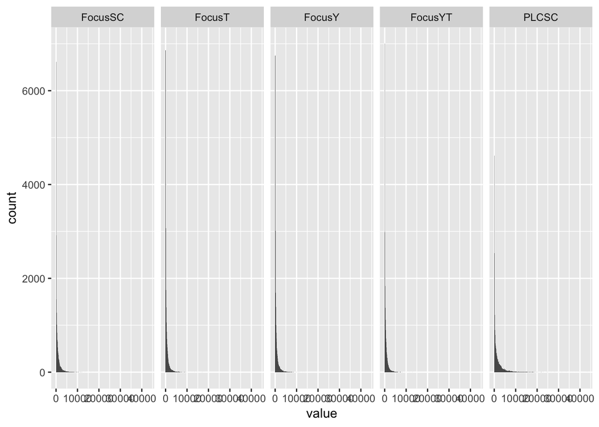

```r
library(ggplot2)
library(tidyr)
ggplot(gather((counts5[,1:5]), cols, value), aes(x = value)) +
       geom_histogram(binwidth=100) + facet_grid(.~cols)
```

Setup up design matrix for DE

```r
Condition = unlist( lapply (colnames(counts5), function(x) sub("S475", "", sub("S449", "", sub("PLC", "", sub("Focus", "", x))))) )
Condition  <- factor(Condition)
Subject2 = unlist( lapply (colnames(counts5), function(x) sub("SC", "", sub("YT", "", sub("T", "", sub("Y", "", x))))) )
Subject2 <- factor(Subject2)
cold <- data.frame("Condition"=Condition, "Subject2"=Subject2) #"sample_name"=colnames(counts4)
design_matrix2 <- model.matrix( ~Subject2 + Condition)
```

FPKM after combinining samples that are “technical” replicates

```r
colnames(counts5) = paste0(colnames(counts5), c(rep("_1", 16), rep("_2", 4)))
y_combined <- DGEList(counts=counts5)
fpkm_matrix = rpkm (y_combined, gene.length=counts1[keep,"Length"], log = FALSE)
```

Heatmap to see how cells cluster by cell type or experimental condition. No replicates because they have been combined.

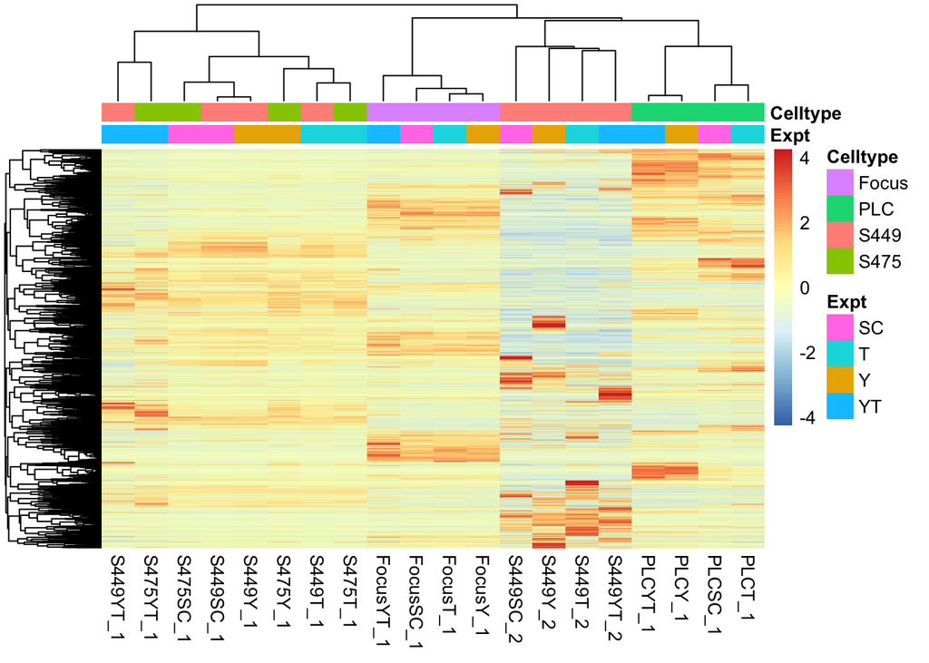

```r
HEATMAP_HEIGHT <- 45 # inchescol
HEATMAP_WIDTH  <- 15
annotation <- data.frame(Expt = Condition, Celltype=Subject2)
rownames(annotation) <- colnames(counts5)
pheatmap(fpkm_matrix,
         , width=HEATMAP_WIDTH, height=HEATMAP_HEIGHT
         , scale="row"  # actually scale each row
         , clustering_distance_rows="correlation" # or: euclidean
         , clustering_distance_cols="correlation"
         , clustering_method="complete"
         , display_numbers=FALSE
         , border_color="#00000000" # note: the last two digits here are the alpha channel/ transparency
         , show_rownames=FALSE, show_colnames = TRUE
         , annotation = annotation
         , fontsize_row=3.5)
```

This heatmap confirms the pattern seen in the dendrogram and PCA plot.

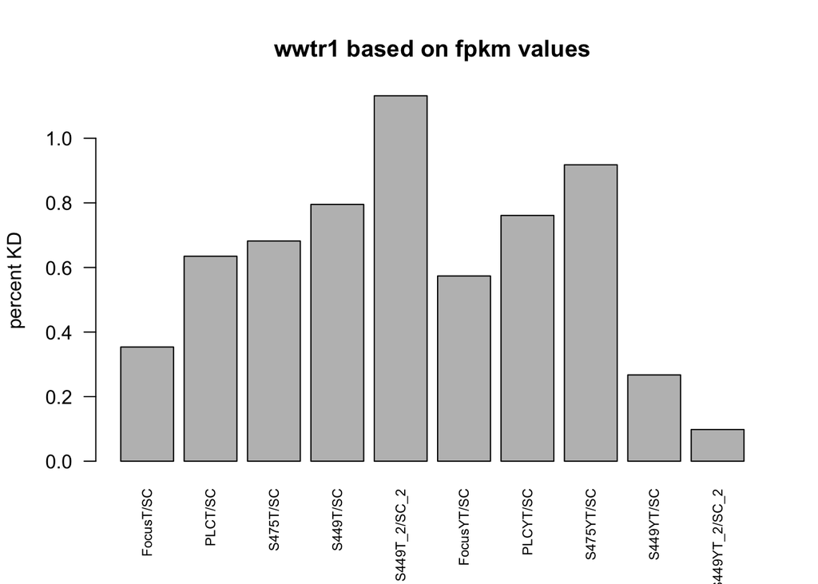

```r
y_combined <- DGEList(counts=counts5)
fpkm_matrix = rpkm (y_combined, gene.length=counts1[keep,"Length"], log = FALSE)
#wwtr1
fpkm_matrix_wwtr1 = fpkm_matrix[which(rownames(fpkm_matrix) == "ENSG00000018408"), ]
fpkm_matrix_wwtr1_percent = c(cbind(
    fpkm_matrix_wwtr1["FocusT_1"]/fpkm_matrix_wwtr1[ "FocusSC_1"]
  , fpkm_matrix_wwtr1["PLCT_1"]/fpkm_matrix_wwtr1[ "PLCSC_1"]
  , fpkm_matrix_wwtr1["S475T_1"]/fpkm_matrix_wwtr1[ "S475SC_1"]
  , fpkm_matrix_wwtr1["S449T_1"]/fpkm_matrix_wwtr1[ "S449SC_1"]
  , fpkm_matrix_wwtr1["S449T_2"]/fpkm_matrix_wwtr1[ "S449SC_2"]
  , fpkm_matrix_wwtr1["FocusYT_1"]/fpkm_matrix_wwtr1[ "FocusSC_1"]
  , fpkm_matrix_wwtr1["PLCYT_1"]/fpkm_matrix_wwtr1[ "PLCSC_1"]
  , fpkm_matrix_wwtr1["S475YT_1"]/fpkm_matrix_wwtr1[ "S475SC_1"]
  , fpkm_matrix_wwtr1["S449YT_1"]/fpkm_matrix_wwtr1[ "S449SC_1"]
  , fpkm_matrix_wwtr1["S449YT_2"]/fpkm_matrix_wwtr1[ "S449SC_2"] ))
names(fpkm_matrix_wwtr1_percent ) = c("FocusT/SC", "PLCT/SC", "S475T/SC", "S449T/SC", "S449T_2/SC_2", "FocusYT/SC", "PLCYT/SC", "S475YT/SC", "S449YT/SC", "S449YT_2/SC_2")

#barplot(fpkm_matrix_wwtr1, las=2)
barplot(fpkm_matrix_wwtr1_percent, las=2, cex.names=.7, ylab= "percent KD", main="wwtr1 based on fpkm values")
```

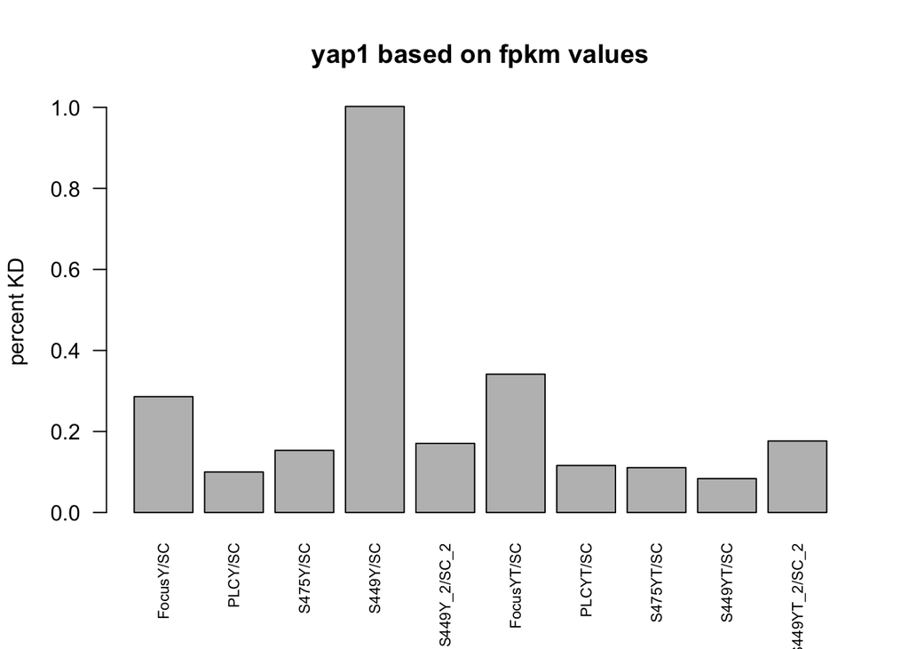

```r
#yap1
fpkm_matrix_yap1 = fpkm_matrix[which(rownames(fpkm_matrix) == "ENSG00000137693"), ]
fpkm_matrix_yap1_percent = c(cbind(
    fpkm_matrix_yap1["FocusY_1"]/fpkm_matrix_yap1[ "FocusSC_1"]
  , fpkm_matrix_yap1["PLCY_1"]/fpkm_matrix_yap1[ "PLCSC_1"]
  , fpkm_matrix_yap1["S475Y_1"]/fpkm_matrix_yap1[ "S475SC_1"]
  , fpkm_matrix_yap1["S449Y_1"]/fpkm_matrix_yap1[ "S449SC_1"]
  , fpkm_matrix_yap1["S449Y_2"]/fpkm_matrix_yap1[ "S449SC_2"]
  , fpkm_matrix_yap1["FocusYT_1"]/fpkm_matrix_yap1[ "FocusSC_1"]
  , fpkm_matrix_yap1["PLCYT_1"]/fpkm_matrix_yap1[ "PLCSC_1"]
  , fpkm_matrix_yap1["S475YT_1"]/fpkm_matrix_yap1[ "S475SC_1"]
  , fpkm_matrix_yap1["S449YT_1"]/fpkm_matrix_yap1[ "S449SC_1"]
  , fpkm_matrix_yap1["S449YT_2"]/fpkm_matrix_yap1[ "S449SC_2"] ))
names(fpkm_matrix_yap1_percent ) = c("FocusY/SC", "PLCY/SC", "S475Y/SC", "S449Y/SC", "S449Y_2/SC_2",  "FocusYT/SC", "PLCYT/SC", "S475YT/SC", "S449YT/SC", "S449YT_2/SC_2")
#barplot(fpkm_matrix_yap1, las=2)
barplot(fpkm_matrix_yap1_percent, las=2,  cex.names=.7, ylab= "percent KD", main = "yap1 based on fpkm values")
```

S449Y_2 appears to have worked! Unfortunately, S447T_2 appears to have failed. It will be more difficult to justify removing samples that didn’t knock down its target.

Fit the model and estimate dispersion value.

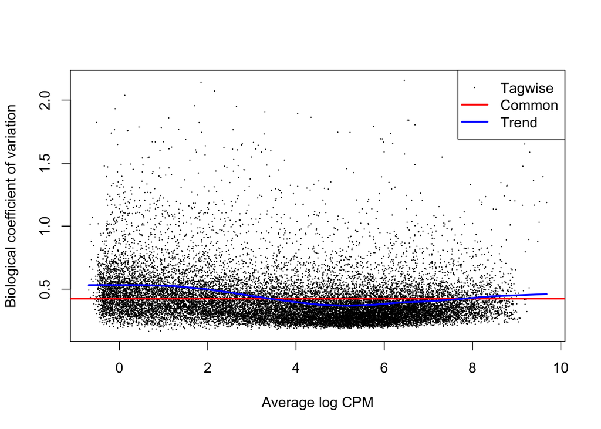

```r
y_for_DE <- DGEList(counts=counts5)
y_for_DE <- calcNormFactors(y_for_DE)
y_for_DE = estimateDisp(y_for_DE, design=design_matrix2)
plotBCV(y_for_DE)
```

```r
fit <- glmFit(y_for_DE, design=design_matrix2, dispersion=y_for_DE$trended.dispersion)
```

```r
lrt_T <- glmLRT(fit,coef = "ConditionT")
topTags(lrt_T)
```

```
## Coefficient:  ConditionT
##                     logFC   logCPM       LR       PValue         FDR
## ENSG00000099974 -2.006653 5.706006 26.33134 2.875843e-07 0.005974276
## ENSG00000099977 -1.855669 5.763359 22.64891 1.944707e-06 0.020199673
## ENSG00000241313 -2.095374 3.204893 19.56340 9.731599e-06 0.067388081
## ENSG00000173432 -1.826397 4.721586 18.15181 2.039758e-05 0.105934851
## ENSG00000159055 -1.600619 4.452517 16.35319 5.256764e-05 0.218408030
## ENSG00000153904 -1.544386 6.922708 15.12611 1.005630e-04 0.348182731
## ENSG00000120937 -1.974061 3.685763 14.18911 1.653245e-04 0.490635855
## ENSG00000138463 -1.438925 4.451771 13.62742 2.229059e-04 0.560473617
## ENSG00000100985  1.645046 8.960509 13.25633 2.716605e-04 0.560473617
## ENSG00000164171  1.476054 7.739998 13.11299 2.932557e-04 0.560473617
```

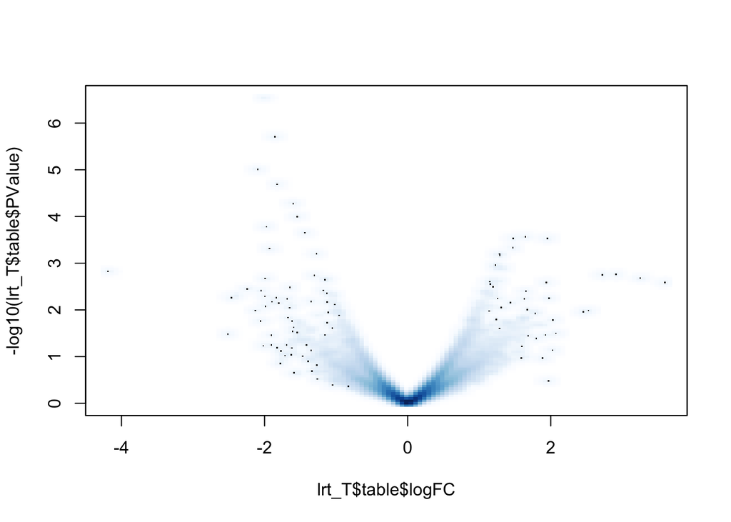

```r
smoothScatter(x=lrt_T$table$logFC, y=-log10(lrt_T$table$PValue))
```

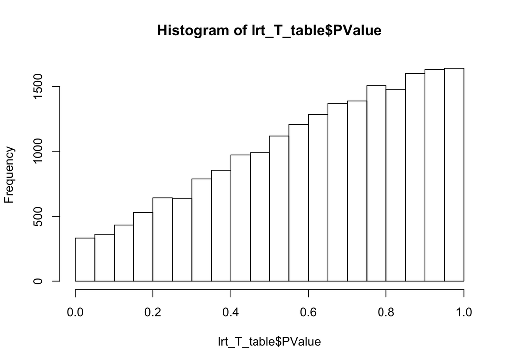

```r
lrt_T_table = data.frame(lrt_T$table, p.adjust(lrt_T$table$PValue, method = "BH"))
colnames(lrt_T_table) = c(colnames(lrt_T$table), "adjPVal_BH")
hist(lrt_T_table$PValue)
```

SC vs Y

```r
lrt_Y <- glmLRT(fit,coef = "ConditionY")
topTags(lrt_Y)
```

```
## Coefficient:  ConditionY
##                     logFC   logCPM       LR       PValue          FDR
## ENSG00000128564  3.018479 5.020437 45.43373 1.578916e-11 2.831606e-07
## ENSG00000267881 -6.874208 4.205956 44.36432 2.726105e-11 2.831606e-07
## ENSG00000280390 -6.070062 4.816677 41.41170 1.233169e-10 8.539285e-07
## ENSG00000086548 -5.326255 5.795668 36.83831 1.283433e-09 6.665509e-06
## ENSG00000107159  2.475514 5.186793 34.59157 4.066642e-09 1.689608e-05
## ENSG00000275266  5.115686 4.340633 31.90978 1.615022e-08 5.591745e-05
## ENSG00000135346  4.722548 3.888785 27.71782 1.403641e-07 4.165605e-04
## ENSG00000181444  2.216028 5.210017 26.67901 2.402175e-07 5.615427e-04
## ENSG00000171951  2.728330 3.797533 26.65453 2.432793e-07 5.615427e-04
## ENSG00000259803  3.329958 2.487696 25.08598 5.482996e-07 1.139038e-03
```

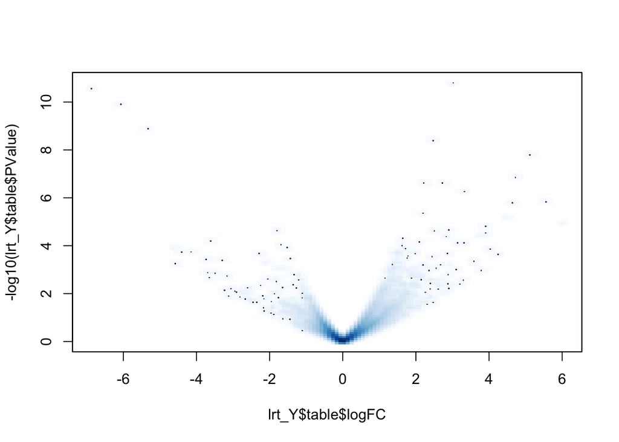

```r
smoothScatter(x=lrt_Y$table$logFC, y=-log10(lrt_Y$table$PValue))
```

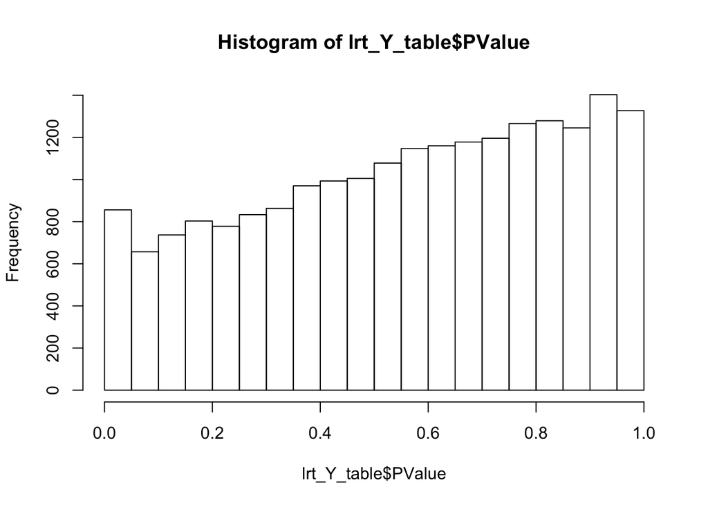

```r
lrt_Y_table = data.frame(lrt_Y$table, p.adjust(lrt_Y$table$PValue, method = "BH"))
colnames(lrt_Y_table) = c(colnames(lrt_Y$table), "adjPVal_BH")
hist(lrt_Y_table$PValue)
```

SC vs YT

```r
lrt_YT <- glmLRT(fit,coef = "ConditionYT")
topTags(lrt_YT)
```

```
## Coefficient:  ConditionYT
##                     logFC   logCPM       LR       PValue          FDR
## ENSG00000181444  4.235559 5.210017 82.17483 1.245664e-19 2.587743e-15
## ENSG00000100985  4.316218 8.960509 70.32358 5.033252e-17 5.228038e-13
## ENSG00000204044  3.807911 7.310962 67.65127 1.951273e-16 1.351192e-12
## ENSG00000128564  3.646862 5.020437 65.20620 6.745701e-16 3.503380e-12
## ENSG00000157601  3.802918 5.546471 64.08434 1.192053e-15 4.952743e-12
## ENSG00000171951  4.275007 3.797533 62.69145 2.417633e-15 8.370653e-12
## ENSG00000137959  6.439643 2.332940 61.04836 5.568989e-15 1.652717e-11
## ENSG00000148344  3.881922 7.533179 58.55653 1.975327e-14 5.129431e-11
## ENSG00000267881 -8.570077 4.205956 54.98280 1.215892e-13 2.806548e-10
## ENSG00000111335  3.156886 5.754504 50.60446 1.129879e-12 2.347210e-09
```

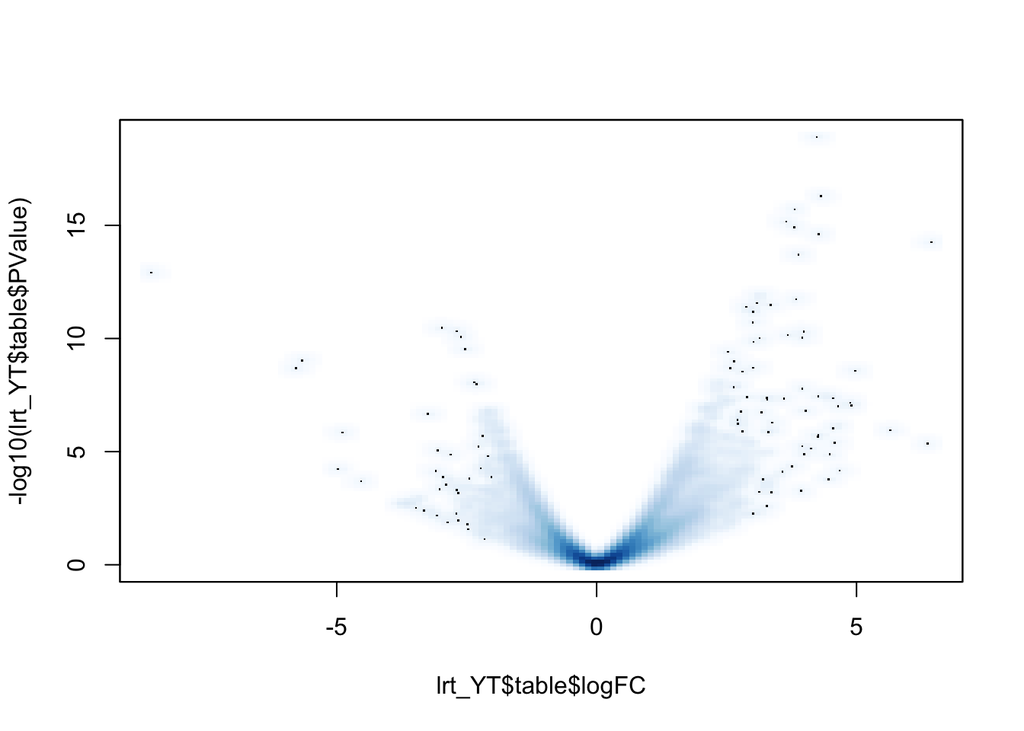

```r
smoothScatter(x=lrt_YT$table$logFC, y=-log10(lrt_YT$table$PValue))
```

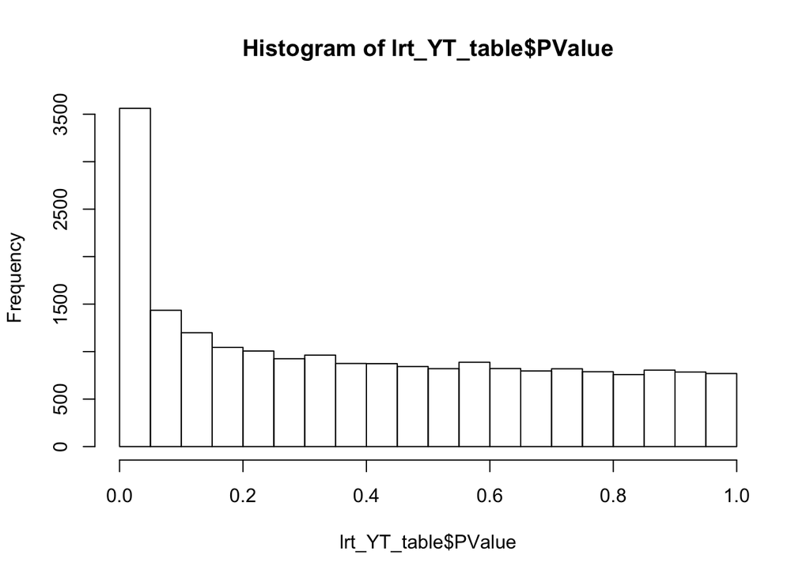

```r
lrt_YT_table = data.frame(lrt_YT$table, p.adjust(lrt_YT$table$PValue, method = "BH"))
colnames(lrt_YT_table) = c(colnames(lrt_YT$table), "adjPVal_BH")
hist(lrt_YT_table$PValue)
```

Format output into excel sheet.

```r
genes = rownames(counts5)
ensembl = useEnsembl(biomart="ensembl", dataset="hsapiens_gene_ensembl")
head(listAttributes(ensembl), 30)
```

```
##                               name
## 1                  ensembl_gene_id
## 2          ensembl_gene_id_version
## 3            ensembl_transcript_id
## 4    ensembl_transcript_id_version
## 5               ensembl_peptide_id
## 6       ensembl_peptide_id_version
## 7                  ensembl_exon_id
## 8                      description
## 9                  chromosome_name
## 10                  start_position
## 11                    end_position
## 12                          strand
## 13                            band
## 14                transcript_start
```

[output cut: 47 more lines]

```r
hgnc_swissprot <- getBM(attributes=c('ensembl_gene_id','hgnc_symbol','description'),filters = 'ensembl_gene_id',  values = genes , mart = ensembl)

fpkm_log_matrix2 = rpkm (y_for_DE, gene.length=counts1[keep,"Length"], log = FALSE)
index = match (genes, hgnc_swissprot$ensembl_gene_id)
results = data.frame(hgnc_swissprot[index,], counts5, fpkm_log_matrix2, lrt_T_table, lrt_Y_table, lrt_YT_table)
colnames(results) = c(
                    colnames(hgnc_swissprot[index,])
                  , unlist(lapply (colnames(counts5), function(x) paste(x, "counts", sep="_")))
                  , unlist(lapply (colnames(fpkm_log_matrix2), function(x) paste(x, "fpkm", sep="_")))
                  , unlist(lapply (colnames(lrt_T_table), function(x) paste(x, "_SC_vs_T", sep="_")))
                  , unlist(lapply (colnames(lrt_Y_table), function(x) paste(x, "_SC_vs_Y", sep="_")))
                  , unlist(lapply (colnames(lrt_YT_table), function(x) paste(x, "_SC_vs_YT", sep="_"))) )
curr_date = format(Sys.time(), "%a_%b_%d_%H_hrs_%M_min_%S_sec_%Y")
write.table(results, paste0("~/Downloads/Chen_", curr_date, ".xls"), row.names=F, col.names=T, sep="\t")
```

Heatmap of DE genes.

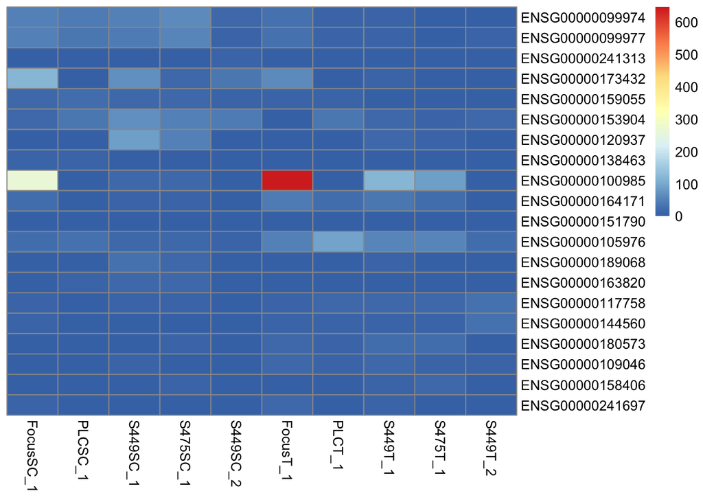

```r
pheatmap(fpkm_log_matrix2[order(lrt_T_table$PValue, decreasing = F)[1:20],c(colnames(fpkm_log_matrix2)[grep("SC", colnames(fpkm_log_matrix2))],"FocusT_1", "PLCT_1", "S449T_1", "S475T_1", "S449T_2")], cluster_rows=FALSE, cluster_cols=FALSE)
```

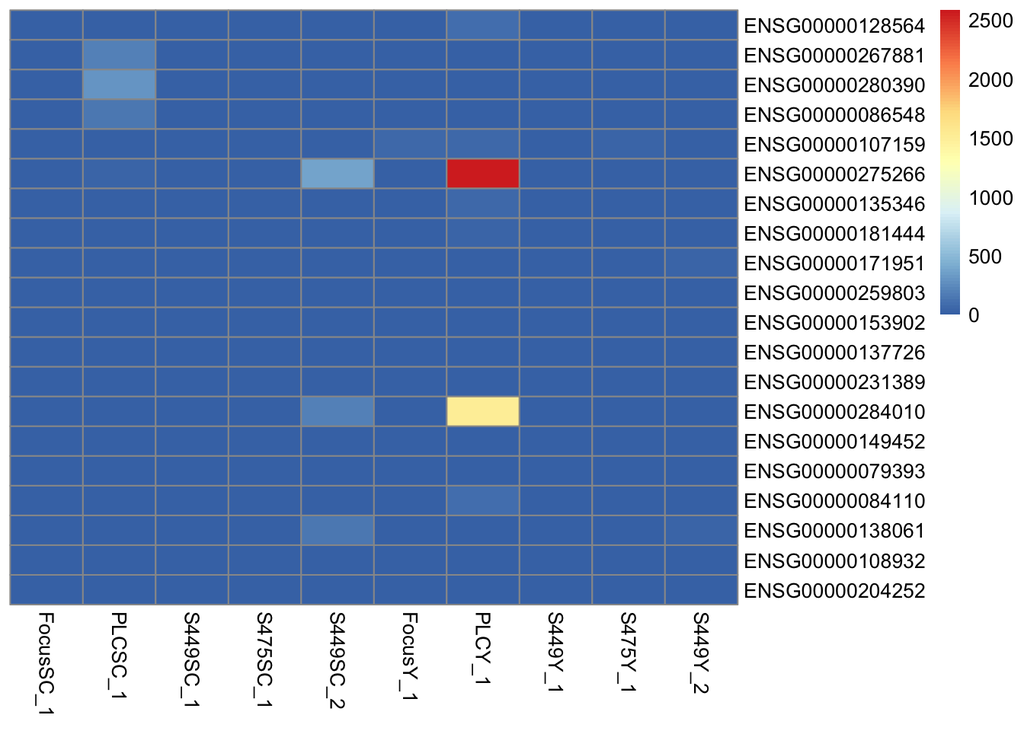

```r
pheatmap(fpkm_log_matrix2[order(lrt_Y_table$PValue, decreasing = F)[1:20],c(colnames(fpkm_log_matrix2)[grep("SC", colnames(fpkm_log_matrix2))],"FocusY_1", "PLCY_1", "S449Y_1", "S475Y_1", "S449Y_2")], cluster_rows=FALSE, cluster_cols=FALSE)
```

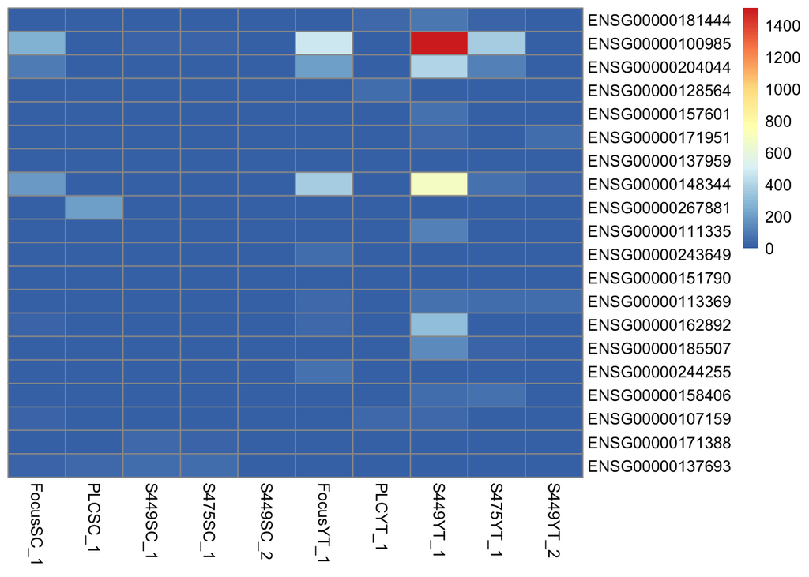

```r
pheatmap(fpkm_log_matrix2[order(lrt_YT_table$PValue, decreasing = F)[1:20],c(colnames(fpkm_log_matrix2)[grep("SC", colnames(fpkm_log_matrix2))],colnames(fpkm_log_matrix2)[grep("YT", colnames(fpkm_log_matrix2))] )], cluster_rows=FALSE, cluster_cols=FALSE)
```

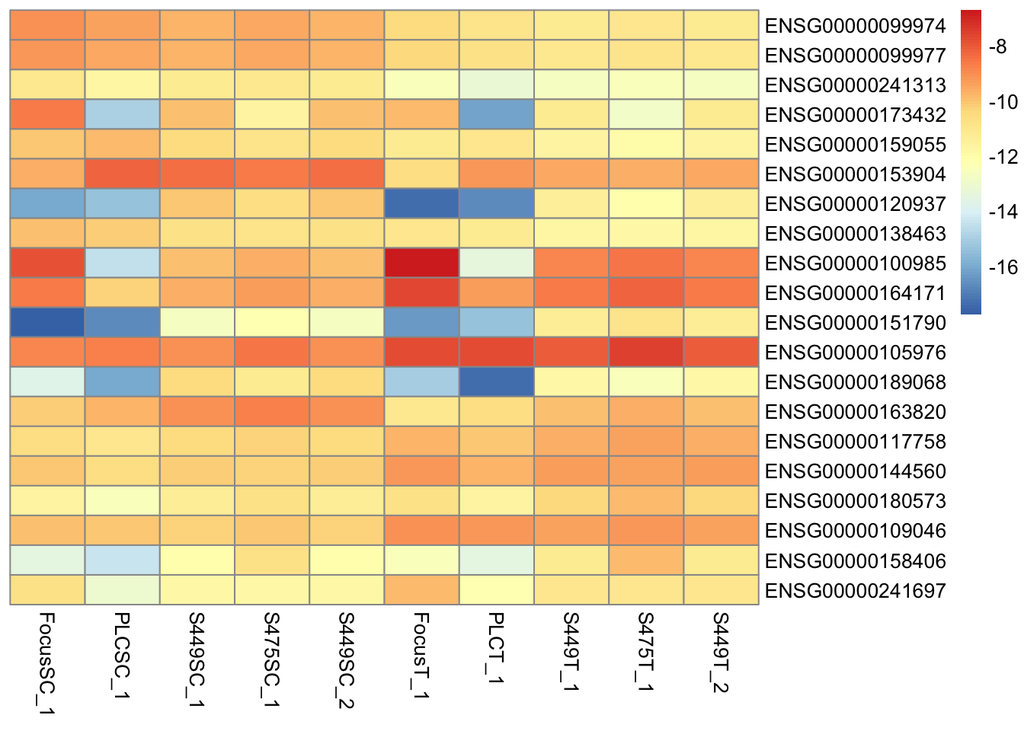

```r
#try this
mean_values = (fit$coefficients %*% t(design_matrix2))
colnames(mean_values) = colnames(counts5)
rownames(mean_values) = rownames(counts5)

pheatmap(mean_values[order(lrt_T_table$PValue, decreasing = F)[1:20],c(colnames(fpkm_log_matrix2)[grep("SC", colnames(fpkm_log_matrix2))],"FocusT_1", "PLCT_1", "S449T_1", "S475T_1", "S449T_2")], cluster_rows=FALSE, cluster_cols=FALSE)
```

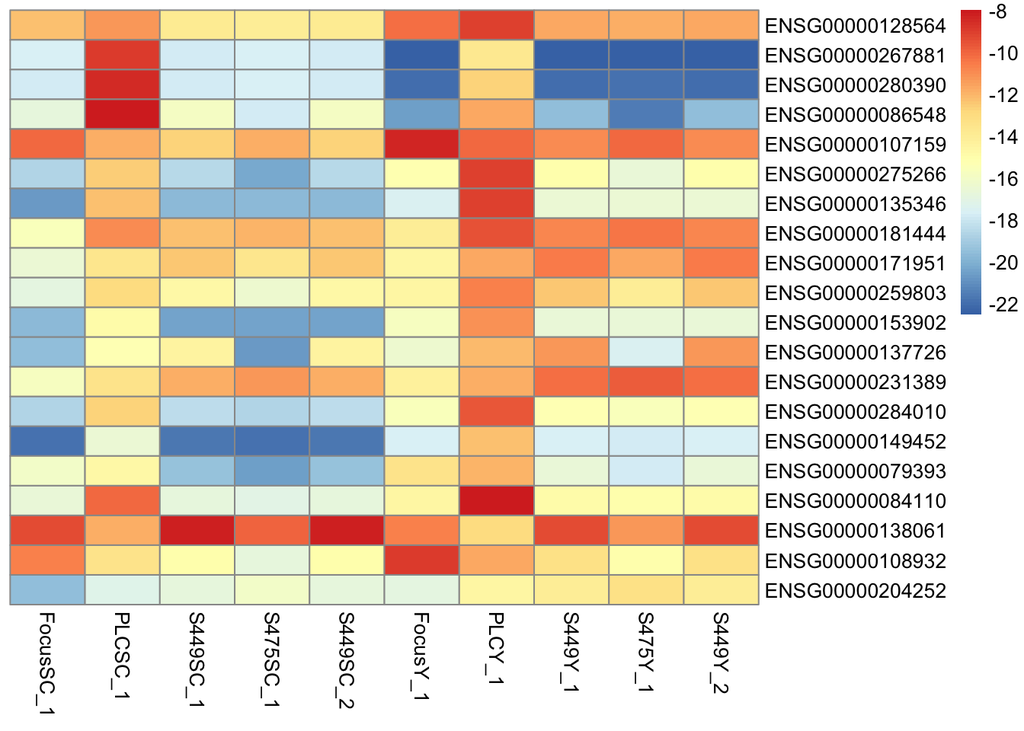

```r
pheatmap(mean_values[order(lrt_Y_table$PValue, decreasing = F)[1:20],c(colnames(fpkm_log_matrix2)[grep("SC", colnames(fpkm_log_matrix2))],"FocusY_1", "PLCY_1", "S449Y_1", "S475Y_1", "S449Y_2")], cluster_rows=FALSE, cluster_cols=FALSE)
```

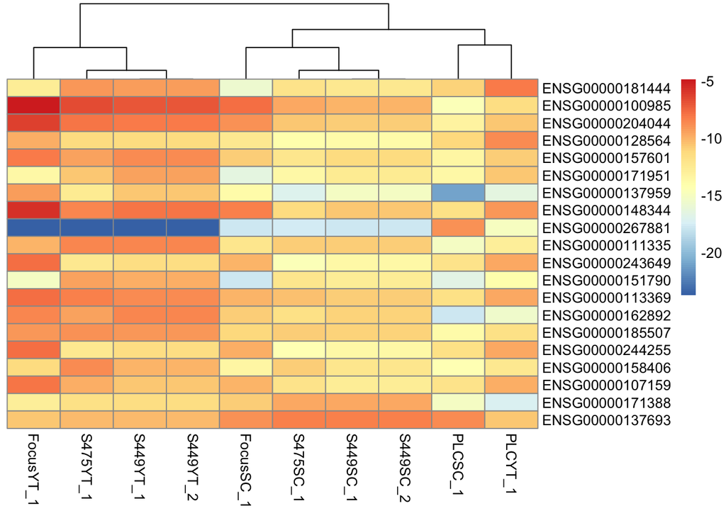

```r
pheatmap(mean_values[order(lrt_YT_table$PValue, decreasing = F)[1:20],c(colnames(fpkm_log_matrix2)[grep("SC", colnames(fpkm_log_matrix2))],colnames(fpkm_log_matrix2)[grep("YT", colnames(fpkm_log_matrix2))] )], cluster_rows=FALSE, cluster_cols=TRUE)
```

```r
#edit column description
write.table(colnames(results), "~/Downloads/column_description.txt", quote=F, col.names=F, row.names=F,sep="\t")
```